# RSV (AREXVY) - Productive cough

OpenSourcePV

Data Lock Point: Data contains VAERS reports processed as of 2023_12_29 (Year_Month_Day). Flag NEW was defined against reports processed as of 2023_11_24.

# 1 Quantitative Signal status

## 1.1 Disproportionality

The vaccine-event combination “RSV (AREXVY) - Productive cough” was **a signal of disproportionate reporting** with an EB05 value of 2.42.

The threshold for being flagged as a signal of disproportionate reporting is an EB05>=2 meaning that there there is a 95% probability that the reporting of Productive cough was at least twice post exposure to RSV (AREXVY) than post all vaccines [1]. Under the assumption of no causality between RSV (AREXVY) and Productive cough and no bias it would have been expected to observe an EBGM of 1.

It means that the quantified causality criterion of strength of association is **met**.

*It is to be noted that the nature of the spontaneous report does not provide reliable estimates of the strength of association (whatever the choice of the disproportionality method) and that some reporting bias or difference in demographic characteristics might explain the (un)observed disproportion*.

## 1.2 Time-to-onset

The vaccine-event combination “RSV (AREXVY) - Productive cough” was **not a signal of unexpected time-to-onset distribution** with a p-value of the two-sample Kolmogorov-Smirnov test being 0.2936886 and distance between the two empirical cumulative distributions being of 22.5373327%.

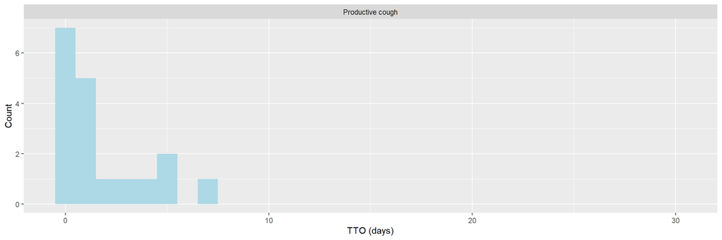

The TTO signal detection method tests if the distribution of Productive cough post RSV (AREXVY) is significantly different from the distribution of Productive cough post other vaccines using a two-sample Kolmogorov-Smirnov test [2]. The threshold for being flagged as a signal of unexpected time-to-onset distribution is a P-value <0.001 and a distance between the two empirical distributions larger than 20%. Under the assumption of no causality and no bias, it would have been expected that the time-to-onset distribution for “Productive cough” would have been the same post RSV (AREXVY) than post other vaccines.

It means that the quantified causality criterion of temporality is **not met**.

*It is to be noted that the nature of the spontaneous report does not provide reliable estimates of the temporal relationship between the exposure and the occurrence of the events as there is the reporting bias over time: the latter the event occurs after exposure, the less chance it has to be reported. Other biases could distort the reported time-to-onset distribution (media attention, etc.)*

## 1.3 Overall

Based on the screening of the Empirical Bayes Geometric Mean (EBGM) and the screening of the time-to-onset distribution,the vaccine-event combination “RSV (AREXVY) - Productive cough” is **considered as quantitative signal**.

# 2 Signal History

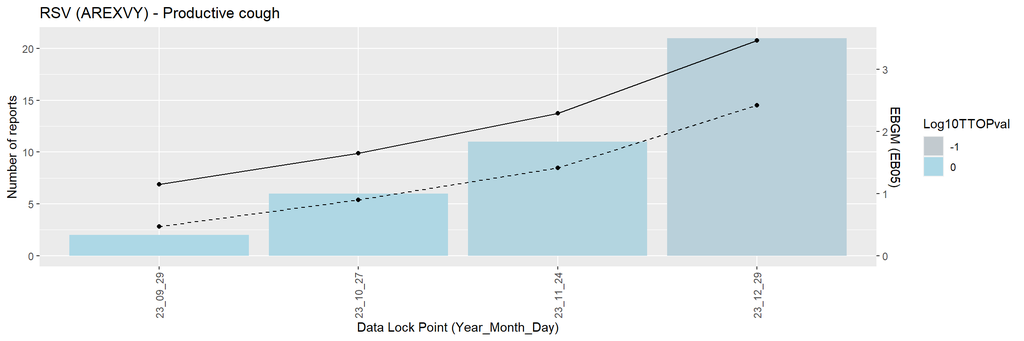

# 3 Case series

## 3.1 Seriousness

A total of 21 reports of Productive cough were received post exposure to RSV (AREXVY). Among them:

- 0 (0.0 %) were fatal cases.
- 0 (0.0 %) were life threatening cases.
- 0 (0.0 %) were hospitalized cases.
- 0 (0.0 %) were emergency room cases.
- 1 (4.8 %) were cases with disabilies.

10 new cases were received since last data refresh.

## 3.2 Demographic characteristics

21 cases of Productive cough post RSV (AREXVY) were reported in VAERS:

- Among them, there were 11 (52.4%) female cases and 10 (47.6%) male cases while the overall female:male ratio is 68:26%.
- The mean (median) age for patients presenting symptoms of Productive cough was 74 (74) years while the overall mean (median) age was 71 (71) years.
- The top 5 contributing US states for patients presenting symptoms of Productive cough were CA ( 9.5 %) , FL ( 9.5 %) , NY ( 9.5 %) , TX ( 9.5 %) , HI ( 4.8 %) while overall the top 5 of contributing US states are NA ( 11.9 %) , FL ( 9.2 %) , CA ( 8.4 %) , NY ( 5.7 %) , TX ( 4.5 %)

# 4 Listing of the cases

Narratives can be made visible clicking on the ⊕ symbol.

|  | VAERS ID | Sex/Age (Years) | Receipt Date | Seriousness status | List of symptoms | New | SYMPTOM_TEXT |
| --- | --- | --- | --- | --- | --- | --- | --- |
| &oplus; | 2717758 | M/77 | 11/25/2023 |  | Arthralgia, Cough, Dysphonia, Fatigue, Productive cough, Respiratory tract congestion | Yes | Not sure if I got Arexvy or the other Probably facility only uses one or the other My GP Doctor checked my chest thoroughly at 10 am and found no congestion I received the injection at 1030 am At 1230… |
| &oplus; | 2718127 | F/79 | 11/27/2023 |  | Cough, Influenza like illness, Nasal congestion, Oropharyngeal pain, Productive cough, Pyrexia, Rhinorrhoea, Sneezing | Yes | Sneeze sore throat dry cough stuffy nose runny nose slight fever flu like symptoms later stage coughing up mucus Today is 11 27 23 I still have the symptoms |
| &oplus; | 2718203 | M/74 | 11/28/2023 |  | Fatigue, Injection site pain, Nasopharyngitis, Productive cough, Respiratory tract congestion, SARS-CoV-2 test negative | Yes | I received RSV vaccine Arevy on 11 16 2023 and developed soreness at injection site cold symptoms congestion and fatigue Still coughing phlegm after 10 days Injection site soreness lasted 3 days Cold … |
| &oplus; | 2720191 | M/NA | 12/01/2023 |  | Cough, Nasal congestion, Productive cough, Upper respiratory tract congestion | Yes | Cough phlegm throat congestion nasal congestion This non serious case was reported by a consumer via call center representative and described the occurrence of cough in a 70 year old male patient who … |
| &oplus; | 2720342 | M/70 | 12/02/2023 |  | Constipation, Cough, Epistaxis, Fatigue, Headache, Oropharyngeal pain, Productive cough, Pyrexia, SARS-CoV-2 test negative, Sneezing | Yes | 11 20 mild headache fatigue 11 21 sore throat sneezing coughing feverish 11 22 sore throat worsened constipated deep coughing with blood in mucus blood in nasal discharge fever used metho lyptus for c… |
| &oplus; | 2722493 | M/75 | 12/09/2023 |  | Cough, Productive cough, Pulmonary congestion, Respiratory tract congestion, SARS-CoV-2 test negative, Sputum discoloured | Yes | 30 minute coughing spells extracting Flem Congestion after 4 days I called the Clinic they checked me out and determined what meds to give me see below |
| &oplus; | 2722745 | F/74 | 12/11/2023 |  | Blood test normal, Chest X-ray normal, Cough, Dyspnoea, Fatigue, Productive cough, Respiratory tract congestion, SARS-CoV-2 test negative, Upper respiratory tract infection, Wheezing | Yes | She got her vaccine she was fine until the following week She started with a dry cough and it slowly progressed into mucousy discharge and coughing and then eventually gradually went into shortness of… |
| &oplus; | 2724596 | F/89 | 12/15/2023 |  | Chest pain, Injection site mass, Lethargy, Pain in extremity, Productive cough | Yes | small lump inside her arm at the injection site patient reported soreness in the arm moderate pain in her lower chest area feeling very lethargic a bit of phlegm in the lungs This non serious case was… |
| &oplus; | 2724855 | F/74 | 12/18/2023 |  | Chest X-ray abnormal, Cough, Eye discharge, Eye inflammation, Myalgia, Pneumonia, Productive cough, Pyrexia | Yes | I contacted the CDC a couple of days ago after my wife 74 had the GSK Arexvy RSV vaccine at a local Pharmacy and seemed to contract the RSV virus Your organization basically said that the RSV vaccine … |
| &oplus; | 2728386 | F/74 | 12/28/2023 |  | Dizziness, Dyspnoea, Hypersensitivity, Productive cough, Pyrexia | Yes | PT told me that she had allergic reaction TO AREXVY VACAINATION PT EXPLAINED THAT SHE HAD FEVER SOB DIZZY HAD COUGH WITH MUCUS ENQUIRED WEA THER THE PT HAD CONTACTED HER PRIMARY CARE MD AS PER PT SHE … |

[output cut: 11 more lines]

# 5 Disclaimer

This analysis is exploratory only and authors cannot be held responsible for any decision made using these data. It is important to distinguish quantitative signals such as disproportionate reporting, unexpected time-to-onset patterns or cluster from safety signals. Only a qualitative review using multiple data source (literature, clinical trials, etc.) and multiple causality criteria assessment could qualify quantitative signals into safety signals.

# 6 References

[1] Dumouchel W. Bayesian data mining in large frequency tables, with an application to the FDA spontaneous reporting system. Am Stat 1999; 53: 177–190.

[2] Van Holle L et al, Using time‐to‐onset for detecting safety signals in spontaneous reports of adverse events following immunization: a proof-of-concept study. Pharmacoepidemiology and Drug Safety 21 (6), 603-610.